# Risk Factor Analysis

## Outcome Variable

**Outcome Variable:** sstunted

## Predictor Variables

**Intervention Variable:** month

**Adjustment Set:**

unadjusted

## Stratifying Variables

The analysis was stratified on these variable(s):

- agecat
- studyid

The following strata were considered:

- agecat: 12 months, studyid: ki0047075b-MAL-ED
- agecat: 12 months, studyid: ki1000108-CMC-V-BCS-2002
- agecat: 12 months, studyid: ki1000108-IRC
- agecat: 12 months, studyid: ki1000109-EE
- agecat: 12 months, studyid: ki1000109-ResPak
- agecat: 12 months, studyid: ki1000304b-SAS-FoodSuppl
- agecat: 12 months, studyid: ki1017093-NIH-Birth
- agecat: 12 months, studyid: ki1066203-TanzaniaChild2
- agecat: 12 months, studyid: ki1112895-Guatemala BSC
- agecat: 12 months, studyid: ki1113344-GMS-Nepal
- agecat: 12 months, studyid: ki1114097-CMIN
- agecat: 12 months, studyid: ki1114097-CONTENT
- agecat: 12 months, studyid: ki1126311-ZVITAMBO
- agecat: 12 months, studyid: ki1148112-LCNI-5
- agecat: 18 months, studyid: ki0047075b-MAL-ED
- agecat: 18 months, studyid: ki1000108-CMC-V-BCS-2002
- agecat: 18 months, studyid: ki1000108-IRC
- agecat: 18 months, studyid: ki1000109-EE
- agecat: 18 months, studyid: ki1000109-ResPak
- agecat: 18 months, studyid: ki1000304b-SAS-FoodSuppl
- agecat: 18 months, studyid: ki1017093-NIH-Birth
- agecat: 18 months, studyid: ki1066203-TanzaniaChild2
- agecat: 18 months, studyid: ki1113344-GMS-Nepal
- agecat: 18 months, studyid: ki1114097-CMIN
- agecat: 18 months, studyid: ki1114097-CONTENT
- agecat: 18 months, studyid: ki1126311-ZVITAMBO
- agecat: 18 months, studyid: ki1148112-LCNI-5
- agecat: 24 months, studyid: ki0047075b-MAL-ED
- agecat: 24 months, studyid: ki1000108-CMC-V-BCS-2002
- agecat: 24 months, studyid: ki1000108-IRC
- agecat: 24 months, studyid: ki1017093-NIH-Birth
- agecat: 24 months, studyid: ki1066203-TanzaniaChild2
- agecat: 24 months, studyid: ki1113344-GMS-Nepal
- agecat: 24 months, studyid: ki1114097-CMIN
- agecat: 24 months, studyid: ki1114097-CONTENT
- agecat: 24 months, studyid: ki1126311-ZVITAMBO
- agecat: 24 months, studyid: ki1148112-LCNI-5
- agecat: 3 months, studyid: ki0047075b-MAL-ED
- agecat: 3 months, studyid: ki1000108-CMC-V-BCS-2002
- agecat: 3 months, studyid: ki1000108-IRC
- agecat: 3 months, studyid: ki1000109-EE
- agecat: 3 months, studyid: ki1000109-ResPak
- agecat: 3 months, studyid: ki1000304b-SAS-FoodSuppl
- agecat: 3 months, studyid: ki1017093-NIH-Birth
- agecat: 3 months, studyid: ki1066203-TanzaniaChild2
- agecat: 3 months, studyid: ki1112895-Guatemala BSC
- agecat: 3 months, studyid: ki1113344-GMS-Nepal
- agecat: 3 months, studyid: ki1114097-CMIN
- agecat: 3 months, studyid: ki1114097-CONTENT
- agecat: 3 months, studyid: ki1126311-ZVITAMBO
- agecat: 6 months, studyid: ki0047075b-MAL-ED
- agecat: 6 months, studyid: ki1000108-CMC-V-BCS-2002
- agecat: 6 months, studyid: ki1000108-IRC
- agecat: 6 months, studyid: ki1000109-EE
- agecat: 6 months, studyid: ki1000109-ResPak
- agecat: 6 months, studyid: ki1000304b-SAS-FoodSuppl
- agecat: 6 months, studyid: ki1017093-NIH-Birth
- agecat: 6 months, studyid: ki1066203-TanzaniaChild2
- agecat: 6 months, studyid: ki1112895-Guatemala BSC
- agecat: 6 months, studyid: ki1113344-GMS-Nepal
- agecat: 6 months, studyid: ki1114097-CMIN
- agecat: 6 months, studyid: ki1114097-CONTENT
- agecat: 6 months, studyid: ki1126311-ZVITAMBO
- agecat: 6 months, studyid: ki1148112-LCNI-5
- agecat: 9 months, studyid: ki0047075b-MAL-ED
- agecat: 9 months, studyid: ki1000108-CMC-V-BCS-2002
- agecat: 9 months, studyid: ki1000108-IRC
- agecat: 9 months, studyid: ki1000109-EE
- agecat: 9 months, studyid: ki1000109-ResPak
- agecat: 9 months, studyid: ki1000304b-SAS-FoodSuppl
- agecat: 9 months, studyid: ki1017093-NIH-Birth
- agecat: 9 months, studyid: ki1066203-TanzaniaChild2
- agecat: 9 months, studyid: ki1112895-Guatemala BSC
- agecat: 9 months, studyid: ki1113344-GMS-Nepal
- agecat: 9 months, studyid: ki1114097-CMIN
- agecat: 9 months, studyid: ki1114097-CONTENT
- agecat: 9 months, studyid: ki1126311-ZVITAMBO
- agecat: 9 months, studyid: ki1148112-LCNI-5
- agecat: Birth, studyid: ki0047075b-MAL-ED
- agecat: Birth, studyid: ki1000108-CMC-V-BCS-2002
- agecat: Birth, studyid: ki1000108-IRC
- agecat: Birth, studyid: ki1000109-EE
- agecat: Birth, studyid: ki1000109-ResPak
- agecat: Birth, studyid: ki1017093-NIH-Birth
- agecat: Birth, studyid: ki1114097-CMIN
- agecat: Birth, studyid: ki1114097-CONTENT
- agecat: Birth, studyid: ki1126311-ZVITAMBO

### Dropped Strata

Some strata were dropped due to rare outcomes:

- agecat: Birth, studyid: ki0047075b-MAL-ED
- agecat: Birth, studyid: ki1000108-CMC-V-BCS-2002
- agecat: Birth, studyid: ki1000108-IRC
- agecat: Birth, studyid: ki1000109-EE
- agecat: Birth, studyid: ki1000109-ResPak
- agecat: Birth, studyid: ki1017093-NIH-Birth
- agecat: Birth, studyid: ki1114097-CMIN
- agecat: Birth, studyid: ki1114097-CONTENT
- agecat: Birth, studyid: ki1126311-ZVITAMBO
- agecat: 3 months, studyid: ki0047075b-MAL-ED
- agecat: 3 months, studyid: ki1000108-CMC-V-BCS-2002
- agecat: 3 months, studyid: ki1000108-IRC
- agecat: 3 months, studyid: ki1000109-EE
- agecat: 3 months, studyid: ki1000109-ResPak
- agecat: 3 months, studyid: ki1000304b-SAS-FoodSuppl
- agecat: 3 months, studyid: ki1017093-NIH-Birth
- agecat: 3 months, studyid: ki1066203-TanzaniaChild2
- agecat: 3 months, studyid: ki1112895-Guatemala BSC
- agecat: 3 months, studyid: ki1113344-GMS-Nepal
- agecat: 3 months, studyid: ki1114097-CMIN
- agecat: 3 months, studyid: ki1114097-CONTENT
- agecat: 6 months, studyid: ki0047075b-MAL-ED
- agecat: 6 months, studyid: ki1000108-CMC-V-BCS-2002
- agecat: 6 months, studyid: ki1000108-IRC
- agecat: 6 months, studyid: ki1000109-EE
- agecat: 6 months, studyid: ki1000109-ResPak
- agecat: 6 months, studyid: ki1000304b-SAS-FoodSuppl
- agecat: 6 months, studyid: ki1017093-NIH-Birth
- agecat: 6 months, studyid: ki1066203-TanzaniaChild2
- agecat: 6 months, studyid: ki1112895-Guatemala BSC
- agecat: 6 months, studyid: ki1113344-GMS-Nepal
- agecat: 6 months, studyid: ki1114097-CMIN
- agecat: 6 months, studyid: ki1114097-CONTENT
- agecat: 6 months, studyid: ki1126311-ZVITAMBO
- agecat: 6 months, studyid: ki1148112-LCNI-5
- agecat: 9 months, studyid: ki0047075b-MAL-ED
- agecat: 9 months, studyid: ki1000108-CMC-V-BCS-2002
- agecat: 9 months, studyid: ki1000108-IRC
- agecat: 9 months, studyid: ki1000109-EE
- agecat: 9 months, studyid: ki1000109-ResPak
- agecat: 9 months, studyid: ki1000304b-SAS-FoodSuppl
- agecat: 9 months, studyid: ki1017093-NIH-Birth
- agecat: 9 months, studyid: ki1066203-TanzaniaChild2
- agecat: 9 months, studyid: ki1112895-Guatemala BSC
- agecat: 9 months, studyid: ki1113344-GMS-Nepal
- agecat: 9 months, studyid: ki1114097-CMIN
- agecat: 9 months, studyid: ki1114097-CONTENT
- agecat: 9 months, studyid: ki1126311-ZVITAMBO
- agecat: 9 months, studyid: ki1148112-LCNI-5
- agecat: 12 months, studyid: ki0047075b-MAL-ED
- agecat: 12 months, studyid: ki1000108-CMC-V-BCS-2002
- agecat: 12 months, studyid: ki1000108-IRC
- agecat: 12 months, studyid: ki1000109-EE
- agecat: 12 months, studyid: ki1000109-ResPak
- agecat: 12 months, studyid: ki1000304b-SAS-FoodSuppl
- agecat: 12 months, studyid: ki1017093-NIH-Birth
- agecat: 12 months, studyid: ki1066203-TanzaniaChild2
- agecat: 12 months, studyid: ki1112895-Guatemala BSC
- agecat: 12 months, studyid: ki1113344-GMS-Nepal
- agecat: 12 months, studyid: ki1114097-CONTENT
- agecat: 12 months, studyid: ki1126311-ZVITAMBO
- agecat: 12 months, studyid: ki1148112-LCNI-5
- agecat: 18 months, studyid: ki1000108-CMC-V-BCS-2002
- agecat: 18 months, studyid: ki1000108-IRC
- agecat: 18 months, studyid: ki1000109-EE
- agecat: 18 months, studyid: ki1000109-ResPak
- agecat: 18 months, studyid: ki1000304b-SAS-FoodSuppl
- agecat: 18 months, studyid: ki1017093-NIH-Birth
- agecat: 18 months, studyid: ki1066203-TanzaniaChild2
- agecat: 18 months, studyid: ki1113344-GMS-Nepal
- agecat: 18 months, studyid: ki1114097-CONTENT
- agecat: 18 months, studyid: ki1126311-ZVITAMBO
- agecat: 18 months, studyid: ki1148112-LCNI-5
- agecat: 24 months, studyid: ki1000108-CMC-V-BCS-2002
- agecat: 24 months, studyid: ki1000108-IRC
- agecat: 24 months, studyid: ki1017093-NIH-Birth
- agecat: 24 months, studyid: ki1066203-TanzaniaChild2
- agecat: 24 months, studyid: ki1113344-GMS-Nepal
- agecat: 24 months, studyid: ki1114097-CONTENT
- agecat: 24 months, studyid: ki1126311-ZVITAMBO
- agecat: 24 months, studyid: ki1148112-LCNI-5

## Methods Detail

We’re interested in the causal parameters $E[Y_a]$ for all values of $a \in \mathcal{A}$. These parameters represent the mean outcome if, possibly contrary to fact, we intervened to set all units to have $A=a$. Under the randomization and positivity assumptions, these are identified by the statistical parameters $\psi_a=E_W[E_{Y|A,W}(Y|A=a,W)]$. In addition, we’re interested in the mean of $Y$, $E[Y]$ under no intervention (the observed mean). We will estimate these parameters by using SuperLearner to fit the relevant likelihood factors – $E_{Y|A,W}(Y|A=a,W)$ and $p(A=a|W)$, and then updating our likelihood fit using a joint TMLE.

For unadjusted analyses ($W=\{\}$), initial likelihoods were estimated using Lrnr_glm to estimate the simple $E(Y|A)$ and Lrnr_mean to estimate $p(A)$. For adjusted analyses, a small library containing Lrnr_glmnet, Lrnr_xgboost, and Lrnr_mean was used.

Having estimated these parameters, we will then use the delta method to estimate relative risks and attributable risks relative to a prespecified baseline level of $A$.

# Results Detail

## Results Plots

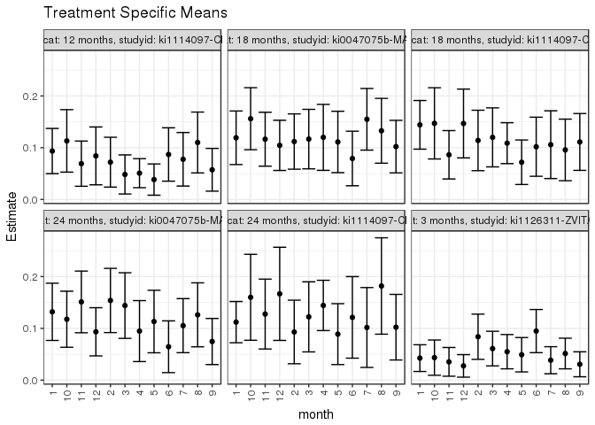

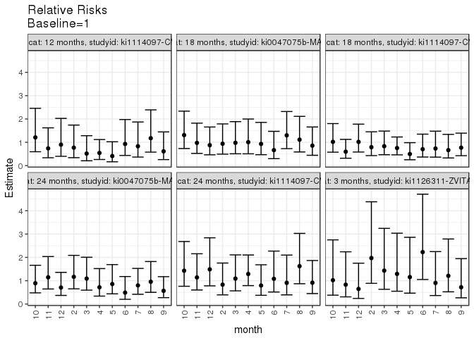

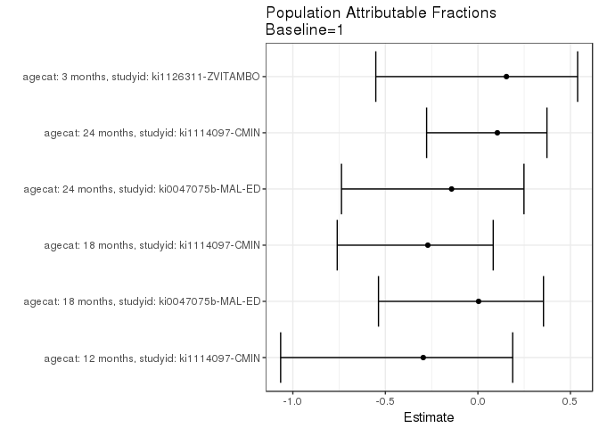

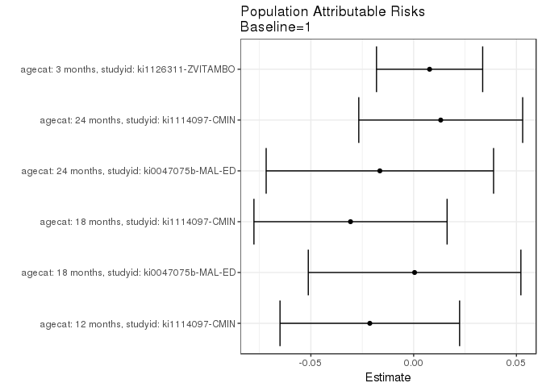

## Data Summary

| agecat | studyid | A | n | nA | nAY0 | nAY1 |
| --- | --- | --- | --- | --- | --- | --- |
| Birth | ki0047075b-MAL-ED | 1 | 1499 | 136 | 131 | 5 |
| Birth | ki0047075b-MAL-ED | 2 | 1499 | 130 | 126 | 4 |
| Birth | ki0047075b-MAL-ED | 3 | 1499 | 125 | 124 | 1 |
| Birth | ki0047075b-MAL-ED | 4 | 1499 | 97 | 95 | 2 |
| Birth | ki0047075b-MAL-ED | 5 | 1499 | 111 | 106 | 5 |
| Birth | ki0047075b-MAL-ED | 6 | 1499 | 94 | 93 | 1 |
| Birth | ki0047075b-MAL-ED | 7 | 1499 | 136 | 132 | 4 |
| Birth | ki0047075b-MAL-ED | 8 | 1499 | 110 | 106 | 4 |
| Birth | ki0047075b-MAL-ED | 9 | 1499 | 137 | 129 | 8 |
| Birth | ki0047075b-MAL-ED | 10 | 1499 | 143 | 137 | 6 |
| Birth | ki0047075b-MAL-ED | 11 | 1499 | 139 | 136 | 3 |
| Birth | ki0047075b-MAL-ED | 12 | 1499 | 141 | 138 | 3 |
| Birth | ki1000108-CMC-V-BCS-2002 | 1 | 90 | 9 | 9 | 0 |
| Birth | ki1000108-CMC-V-BCS-2002 | 2 | 90 | 1 | 1 | 0 |
| Birth | ki1000108-CMC-V-BCS-2002 | 3 | 90 | 8 | 7 | 1 |
| Birth | ki1000108-CMC-V-BCS-2002 | 4 | 90 | 9 | 9 | 0 |
| Birth | ki1000108-CMC-V-BCS-2002 | 5 | 90 | 11 | 11 | 0 |
| Birth | ki1000108-CMC-V-BCS-2002 | 6 | 90 | 9 | 9 | 0 |
| Birth | ki1000108-CMC-V-BCS-2002 | 7 | 90 | 7 | 7 | 0 |
| Birth | ki1000108-CMC-V-BCS-2002 | 8 | 90 | 4 | 4 | 0 |
| Birth | ki1000108-CMC-V-BCS-2002 | 9 | 90 | 7 | 7 | 0 |
| Birth | ki1000108-CMC-V-BCS-2002 | 10 | 90 | 10 | 9 | 1 |
| Birth | ki1000108-CMC-V-BCS-2002 | 11 | 90 | 11 | 11 | 0 |
| Birth | ki1000108-CMC-V-BCS-2002 | 12 | 90 | 4 | 3 | 1 |
| Birth | ki1000108-IRC | 1 | 388 | 34 | 31 | 3 |
| Birth | ki1000108-IRC | 2 | 388 | 25 | 24 | 1 |
| Birth | ki1000108-IRC | 3 | 388 | 27 | 27 | 0 |
| Birth | ki1000108-IRC | 4 | 388 | 22 | 22 | 0 |
| Birth | ki1000108-IRC | 5 | 388 | 21 | 20 | 1 |
| Birth | ki1000108-IRC | 6 | 388 | 34 | 31 | 3 |

[output cut: 1146 more lines]

## Results Table

### Parameter: TSM

| agecat | studyid | intervention_level | baseline_level | estimate | ci_lower | ci_upper |
| --- | --- | --- | --- | --- | --- | --- |
| 3 months | ki1126311-ZVITAMBO | 1 | NA | 0.0425532 | 0.0167405 | 0.0683659 |
| 3 months | ki1126311-ZVITAMBO | 2 | NA | 0.0838710 | 0.0402232 | 0.1275188 |
| 3 months | ki1126311-ZVITAMBO | 3 | NA | 0.0609137 | 0.0275080 | 0.0943194 |
| 3 months | ki1126311-ZVITAMBO | 4 | NA | 0.0549451 | 0.0218319 | 0.0880582 |
| 3 months | ki1126311-ZVITAMBO | 5 | NA | 0.0490798 | 0.0159076 | 0.0822519 |
| 3 months | ki1126311-ZVITAMBO | 6 | NA | 0.0947368 | 0.0530869 | 0.1363867 |
| 3 months | ki1126311-ZVITAMBO | 7 | NA | 0.0384615 | 0.0123213 | 0.0646017 |
| 3 months | ki1126311-ZVITAMBO | 8 | NA | 0.0514019 | 0.0218103 | 0.0809934 |
| 3 months | ki1126311-ZVITAMBO | 9 | NA | 0.0306122 | 0.0064903 | 0.0547342 |
| 3 months | ki1126311-ZVITAMBO | 10 | NA | 0.0434783 | 0.0094462 | 0.0775103 |
| 3 months | ki1126311-ZVITAMBO | 11 | NA | 0.0352941 | 0.0075502 | 0.0630381 |
| 3 months | ki1126311-ZVITAMBO | 12 | NA | 0.0275229 | 0.0058008 | 0.0492451 |
| 12 months | ki1114097-CMIN | 1 | NA | 0.0935673 | 0.0499039 | 0.1372306 |
| 12 months | ki1114097-CMIN | 2 | NA | 0.0720721 | 0.0239477 | 0.1201964 |
| 12 months | ki1114097-CMIN | 3 | NA | 0.0483871 | 0.0106064 | 0.0861678 |
| 12 months | ki1114097-CMIN | 4 | NA | 0.0508475 | 0.0228104 | 0.0788845 |
| 12 months | ki1114097-CMIN | 5 | NA | 0.0384615 | 0.0082745 | 0.0686486 |
| 12 months | ki1114097-CMIN | 6 | NA | 0.0869565 | 0.0354415 | 0.1384715 |
| 12 months | ki1114097-CMIN | 7 | NA | 0.0776699 | 0.0259644 | 0.1293754 |
| 12 months | ki1114097-CMIN | 8 | NA | 0.1100917 | 0.0513127 | 0.1688708 |
| 12 months | ki1114097-CMIN | 9 | NA | 0.0573770 | 0.0160966 | 0.0986575 |
| 12 months | ki1114097-CMIN | 10 | NA | 0.1132075 | 0.0528709 | 0.1735442 |
| 12 months | ki1114097-CMIN | 11 | NA | 0.0692308 | 0.0255807 | 0.1128808 |
| 12 months | ki1114097-CMIN | 12 | NA | 0.0842105 | 0.0283500 | 0.1400710 |
| 18 months | ki0047075b-MAL-ED | 1 | NA | 0.1192053 | 0.0675059 | 0.1709047 |
| 18 months | ki0047075b-MAL-ED | 2 | NA | 0.1119403 | 0.0585392 | 0.1653414 |
| 18 months | ki0047075b-MAL-ED | 3 | NA | 0.1166667 | 0.0592109 | 0.1741224 |
| 18 months | ki0047075b-MAL-ED | 4 | NA | 0.1200000 | 0.0562881 | 0.1837119 |
| 18 months | ki0047075b-MAL-ED | 5 | NA | 0.1111111 | 0.0518214 | 0.1704008 |
| 18 months | ki0047075b-MAL-ED | 6 | NA | 0.0792079 | 0.0265222 | 0.1318937 |
| 18 months | ki0047075b-MAL-ED | 7 | NA | 0.1549296 | 0.0953965 | 0.2144626 |
| 18 months | ki0047075b-MAL-ED | 8 | NA | 0.1327434 | 0.0701642 | 0.1953225 |
| 18 months | ki0047075b-MAL-ED | 9 | NA | 0.1021898 | 0.0514528 | 0.1529267 |
| 18 months | ki0047075b-MAL-ED | 10 | NA | 0.1560284 | 0.0961121 | 0.2159446 |
| 18 months | ki0047075b-MAL-ED | 11 | NA | 0.1164384 | 0.0643934 | 0.1684833 |
| 18 months | ki0047075b-MAL-ED | 12 | NA | 0.1045752 | 0.0560718 | 0.1530785 |
| 18 months | ki1114097-CMIN | 1 | NA | 0.1441860 | 0.0972165 | 0.1911556 |
| 18 months | ki1114097-CMIN | 2 | NA | 0.1140351 | 0.0556692 | 0.1724010 |
| 18 months | ki1114097-CMIN | 3 | NA | 0.1200000 | 0.0630149 | 0.1769851 |
| 18 months | ki1114097-CMIN | 4 | NA | 0.1087866 | 0.0692987 | 0.1482745 |
| 18 months | ki1114097-CMIN | 5 | NA | 0.0719424 | 0.0289733 | 0.1149116 |
| 18 months | ki1114097-CMIN | 6 | NA | 0.1018519 | 0.0447920 | 0.1589117 |
| 18 months | ki1114097-CMIN | 7 | NA | 0.1058824 | 0.0404513 | 0.1713134 |
| 18 months | ki1114097-CMIN | 8 | NA | 0.0957447 | 0.0362438 | 0.1552455 |
| 18 months | ki1114097-CMIN | 9 | NA | 0.1111111 | 0.0562201 | 0.1660022 |
| 18 months | ki1114097-CMIN | 10 | NA | 0.1470588 | 0.0783062 | 0.2158114 |
| 18 months | ki1114097-CMIN | 11 | NA | 0.0863309 | 0.0396269 | 0.1330350 |
| 18 months | ki1114097-CMIN | 12 | NA | 0.1467890 | 0.0803312 | 0.2132468 |
| 24 months | ki0047075b-MAL-ED | 1 | NA | 0.1319444 | 0.0766499 | 0.1872390 |
| 24 months | ki0047075b-MAL-ED | 2 | NA | 0.1538462 | 0.0918035 | 0.2158888 |
| 24 months | ki0047075b-MAL-ED | 3 | NA | 0.1440678 | 0.0806872 | 0.2074484 |
| 24 months | ki0047075b-MAL-ED | 4 | NA | 0.0947368 | 0.0358282 | 0.1536455 |
| 24 months | ki0047075b-MAL-ED | 5 | NA | 0.1132075 | 0.0528697 | 0.1735454 |
| 24 months | ki0047075b-MAL-ED | 6 | NA | 0.0645161 | 0.0145697 | 0.1144626 |
| 24 months | ki0047075b-MAL-ED | 7 | NA | 0.1052632 | 0.0530892 | 0.1574371 |
| 24 months | ki0047075b-MAL-ED | 8 | NA | 0.1261261 | 0.0643445 | 0.1879078 |
| 24 months | ki0047075b-MAL-ED | 9 | NA | 0.0746269 | 0.0301179 | 0.1191358 |
| 24 months | ki0047075b-MAL-ED | 10 | NA | 0.1176471 | 0.0634799 | 0.1718142 |
| 24 months | ki0047075b-MAL-ED | 11 | NA | 0.1510791 | 0.0915236 | 0.2106347 |
| 24 months | ki0047075b-MAL-ED | 12 | NA | 0.0933333 | 0.0467650 | 0.1399017 |
| 24 months | ki1114097-CMIN | 1 | NA | 0.1120332 | 0.0721960 | 0.1518704 |
| 24 months | ki1114097-CMIN | 2 | NA | 0.0930233 | 0.0316088 | 0.1544377 |
| 24 months | ki1114097-CMIN | 3 | NA | 0.1222222 | 0.0545248 | 0.1899196 |
| 24 months | ki1114097-CMIN | 4 | NA | 0.1442786 | 0.0956832 | 0.1928740 |
| 24 months | ki1114097-CMIN | 5 | NA | 0.0888889 | 0.0300704 | 0.1477074 |
| 24 months | ki1114097-CMIN | 6 | NA | 0.1212121 | 0.0424407 | 0.1999836 |
| 24 months | ki1114097-CMIN | 7 | NA | 0.1016949 | 0.0245404 | 0.1788494 |
| 24 months | ki1114097-CMIN | 8 | NA | 0.1818182 | 0.0887294 | 0.2749070 |
| 24 months | ki1114097-CMIN | 9 | NA | 0.1022727 | 0.0389388 | 0.1656067 |
| 24 months | ki1114097-CMIN | 10 | NA | 0.1600000 | 0.0769968 | 0.2430032 |
| 24 months | ki1114097-CMIN | 11 | NA | 0.1276596 | 0.0601708 | 0.1951484 |
| 24 months | ki1114097-CMIN | 12 | NA | 0.1666667 | 0.0767195 | 0.2566139 |

### Parameter: E(Y)

| agecat | studyid | intervention_level | baseline_level | estimate | ci_lower | ci_upper |
| --- | --- | --- | --- | --- | --- | --- |
| 3 months | ki1126311-ZVITAMBO | NA | NA | 0.0503089 | 0.0495097 | 0.0511082 |
| 12 months | ki1114097-CMIN | NA | NA | 0.0722433 | 0.0711059 | 0.0733808 |
| 18 months | ki0047075b-MAL-ED | NA | NA | 0.1196636 | 0.1186468 | 0.1206805 |
| 18 months | ki1114097-CMIN | NA | NA | 0.1134796 | 0.1123521 | 0.1146071 |
| 24 months | ki0047075b-MAL-ED | NA | NA | 0.1155138 | 0.1141263 | 0.1169012 |
| 24 months | ki1114097-CMIN | NA | NA | 0.1252046 | 0.1237518 | 0.1266574 |

### Parameter: RR

| agecat | studyid | intervention_level | baseline_level | estimate | ci_lower | ci_upper |
| --- | --- | --- | --- | --- | --- | --- |
| 3 months | ki1126311-ZVITAMBO | 2 | 1 | 1.9709677 | 0.8862808 | 4.3831638 |
| 3 months | ki1126311-ZVITAMBO | 3 | 1 | 1.4314721 | 0.6318853 | 3.2428546 |
| 3 months | ki1126311-ZVITAMBO | 4 | 1 | 1.2912088 | 0.5490858 | 3.0363565 |
| 3 months | ki1126311-ZVITAMBO | 5 | 1 | 1.1533742 | 0.4651100 | 2.8601236 |
| 3 months | ki1126311-ZVITAMBO | 6 | 1 | 2.2263158 | 1.0525192 | 4.7091607 |
| 3 months | ki1126311-ZVITAMBO | 7 | 1 | 0.9038462 | 0.3634647 | 2.2476405 |
| 3 months | ki1126311-ZVITAMBO | 8 | 1 | 1.2079439 | 0.5234205 | 2.7876794 |
| 3 months | ki1126311-ZVITAMBO | 9 | 1 | 0.7193878 | 0.2661277 | 1.9446255 |
| 3 months | ki1126311-ZVITAMBO | 10 | 1 | 1.0217391 | 0.3795512 | 2.7504874 |
| 3 months | ki1126311-ZVITAMBO | 11 | 1 | 0.8294118 | 0.3072929 | 2.2386582 |
| 3 months | ki1126311-ZVITAMBO | 12 | 1 | 0.6467890 | 0.2390330 | 1.7501185 |
| 12 months | ki1114097-CMIN | 2 | 1 | 0.7702703 | 0.3410782 | 1.7395317 |
| 12 months | ki1114097-CMIN | 3 | 1 | 0.5171371 | 0.2082386 | 1.2842514 |
| 12 months | ki1114097-CMIN | 4 | 1 | 0.5434322 | 0.2638938 | 1.1190811 |
| 12 months | ki1114097-CMIN | 5 | 1 | 0.4110578 | 0.1649467 | 1.0243828 |
| 12 months | ki1114097-CMIN | 6 | 1 | 0.9293478 | 0.4371787 | 1.9755936 |
| 12 months | ki1114097-CMIN | 7 | 1 | 0.8300971 | 0.3681776 | 1.8715456 |
| 12 months | ki1114097-CMIN | 8 | 1 | 1.1766055 | 0.5789917 | 2.3910544 |
| 12 months | ki1114097-CMIN | 9 | 1 | 0.6132172 | 0.2601279 | 1.4455789 |
| 12 months | ki1114097-CMIN | 10 | 1 | 1.2099057 | 0.5957976 | 2.4569951 |
| 12 months | ki1114097-CMIN | 11 | 1 | 0.7399038 | 0.3376847 | 1.6212099 |
| 12 months | ki1114097-CMIN | 12 | 1 | 0.9000000 | 0.3999552 | 2.0252266 |
| 18 months | ki0047075b-MAL-ED | 2 | 1 | 0.9390547 | 0.4928214 | 1.7893374 |
| 18 months | ki0047075b-MAL-ED | 3 | 1 | 0.9787037 | 0.5077578 | 1.8864526 |
| 18 months | ki0047075b-MAL-ED | 4 | 1 | 1.0066667 | 0.5071694 | 1.9981050 |
| 18 months | ki0047075b-MAL-ED | 5 | 1 | 0.9320988 | 0.4686286 | 1.8539375 |
| 18 months | ki0047075b-MAL-ED | 6 | 1 | 0.6644664 | 0.3003430 | 1.4700383 |
| 18 months | ki0047075b-MAL-ED | 7 | 1 | 1.2996870 | 0.7281003 | 2.3199913 |
| 18 months | ki0047075b-MAL-ED | 8 | 1 | 1.1135693 | 0.5868367 | 2.1130865 |
| 18 months | ki0047075b-MAL-ED | 9 | 1 | 0.8572587 | 0.4434095 | 1.6573677 |
| 18 months | ki0047075b-MAL-ED | 10 | 1 | 1.3089046 | 0.7333856 | 2.3360580 |
| 18 months | ki0047075b-MAL-ED | 11 | 1 | 0.9767884 | 0.5239878 | 1.8208738 |
| 18 months | ki0047075b-MAL-ED | 12 | 1 | 0.8772694 | 0.4648985 | 1.6554186 |
| 18 months | ki1114097-CMIN | 2 | 1 | 0.7908885 | 0.4311517 | 1.4507764 |
| 18 months | ki1114097-CMIN | 3 | 1 | 0.8322581 | 0.4679092 | 1.4803160 |
| 18 months | ki1114097-CMIN | 4 | 1 | 0.7544878 | 0.4632721 | 1.2287635 |
| 18 months | ki1114097-CMIN | 5 | 1 | 0.4989557 | 0.2526957 | 0.9852037 |
| 18 months | ki1114097-CMIN | 6 | 1 | 0.7063919 | 0.3694888 | 1.3504862 |
| 18 months | ki1114097-CMIN | 7 | 1 | 0.7343454 | 0.3651891 | 1.4766681 |
| 18 months | ki1114097-CMIN | 8 | 1 | 0.6640357 | 0.3292046 | 1.3394204 |
| 18 months | ki1114097-CMIN | 9 | 1 | 0.7706093 | 0.4264213 | 1.3926104 |
| 18 months | ki1114097-CMIN | 10 | 1 | 1.0199241 | 0.5768992 | 1.8031663 |
| 18 months | ki1114097-CMIN | 11 | 1 | 0.5987468 | 0.3184113 | 1.1258953 |
| 18 months | ki1114097-CMIN | 12 | 1 | 1.0180527 | 0.5828260 | 1.7782859 |
| 24 months | ki0047075b-MAL-ED | 2 | 1 | 1.1659919 | 0.6517949 | 2.0858358 |
| 24 months | ki0047075b-MAL-ED | 3 | 1 | 1.0918822 | 0.5947062 | 2.0046989 |
| 24 months | ki0047075b-MAL-ED | 4 | 1 | 0.7180055 | 0.3392126 | 1.5197899 |
| 24 months | ki0047075b-MAL-ED | 5 | 1 | 0.8579940 | 0.4355409 | 1.6902057 |
| 24 months | ki0047075b-MAL-ED | 6 | 1 | 0.4889643 | 0.2027492 | 1.1792210 |
| 24 months | ki0047075b-MAL-ED | 7 | 1 | 0.7977839 | 0.4168662 | 1.5267708 |
| 24 months | ki0047075b-MAL-ED | 8 | 1 | 0.9559033 | 0.5017050 | 1.8212916 |
| 24 months | ki0047075b-MAL-ED | 9 | 1 | 0.5655931 | 0.2728559 | 1.1723973 |
| 24 months | ki0047075b-MAL-ED | 10 | 1 | 0.8916409 | 0.4784155 | 1.6617846 |
| 24 months | ki0047075b-MAL-ED | 11 | 1 | 1.1450208 | 0.6440888 | 2.0355464 |
| 24 months | ki0047075b-MAL-ED | 12 | 1 | 0.7073684 | 0.3686917 | 1.3571503 |
| 24 months | ki1114097-CMIN | 2 | 1 | 0.8303187 | 0.3922642 | 1.7575632 |
| 24 months | ki1114097-CMIN | 3 | 1 | 1.0909465 | 0.5648711 | 2.1069662 |
| 24 months | ki1114097-CMIN | 4 | 1 | 1.2878202 | 0.7891256 | 2.1016690 |
| 24 months | ki1114097-CMIN | 5 | 1 | 0.7934157 | 0.3743345 | 1.6816738 |
| 24 months | ki1114097-CMIN | 6 | 1 | 1.0819304 | 0.5157984 | 2.2694398 |
| 24 months | ki1114097-CMIN | 7 | 1 | 0.9077213 | 0.3927041 | 2.0981651 |
| 24 months | ki1114097-CMIN | 8 | 1 | 1.6228956 | 0.8701030 | 3.0269865 |
| 24 months | ki1114097-CMIN | 9 | 1 | 0.9128788 | 0.4469781 | 1.8644040 |
| 24 months | ki1114097-CMIN | 10 | 1 | 1.4281481 | 0.7614286 | 2.6786585 |
| 24 months | ki1114097-CMIN | 11 | 1 | 1.1394799 | 0.6025712 | 2.1547903 |
| 24 months | ki1114097-CMIN | 12 | 1 | 1.4876543 | 0.7795059 | 2.8391258 |

### Parameter: PAR

| agecat | studyid | intervention_level | baseline_level | estimate | ci_lower | ci_upper |
| --- | --- | --- | --- | --- | --- | --- |
| 3 months | ki1126311-ZVITAMBO | 1 | NA | 0.0077557 | -0.0180693 | 0.0335808 |
| 12 months | ki1114097-CMIN | 1 | NA | -0.0213239 | -0.0650021 | 0.0223543 |
| 18 months | ki0047075b-MAL-ED | 1 | NA | 0.0004584 | -0.0512510 | 0.0521677 |
| 18 months | ki1114097-CMIN | 1 | NA | -0.0307064 | -0.0776895 | 0.0162767 |
| 24 months | ki0047075b-MAL-ED | 1 | NA | -0.0164307 | -0.0717426 | 0.0388812 |
| 24 months | ki1114097-CMIN | 1 | NA | 0.0131714 | -0.0266923 | 0.0530351 |

### Parameter: PAF

| agecat | studyid | intervention_level | baseline_level | estimate | ci_lower | ci_upper |
| --- | --- | --- | --- | --- | --- | --- |
| 3 months | ki1126311-ZVITAMBO | 1 | NA | 0.1541620 | -0.5517433 | 0.5389431 |
| 12 months | ki1114097-CMIN | 1 | NA | -0.2951677 | -1.0658839 | 0.1880185 |
| 18 months | ki0047075b-MAL-ED | 1 | NA | 0.0038303 | -0.5371742 | 0.3544297 |
| 18 months | ki1114097-CMIN | 1 | NA | -0.2705897 | -0.7601326 | 0.0827973 |
| 24 months | ki0047075b-MAL-ED | 1 | NA | -0.1422400 | -0.7371356 | 0.2489290 |
| 24 months | ki1114097-CMIN | 1 | NA | 0.1051989 | -0.2771353 | 0.3730743 |